# NFC North: Fourth-Quarter Penalties in Close Games, 2018-2022

Applied Statistics 1 group project - Gerry’s divisional analysis

Gerry

November 14, 2026

## 1. Question and scope

I use 2018-2022 regular-season games involving at least one NFC North team (CHI, DET, GB, MIN) to ask whether the **home-away difference in fourth-quarter penalties** changed in the COVID-affected 2020 season relative to 2018-2019 and 2021-2022. My angle is **close games**, defined below, because crowd effects on officiating (if any) should matter most when the game is still undecided.

The unit of analysis is the **game**, not the play. Penalty counts are compared as per-game totals and as rates per 100 fourth-quarter plays; inference is on game-level home-minus-away differentials. This avoids treating penalties within a game (or plays within a drive) as independent observations.

## 2. Data loading and filtering

```r
nfc_north <- c("CHI", "DET", "GB", "MIN")
seasons <- 2018:2022
close_threshold <- 8   # |home - away| at the start of Q4
```

```r
schedule_all <- load_schedules(seasons)

nfc_north_schedule <- schedule_all %>%
  filter(
    game_type == "REG",                 # regular season only
    location == "Home",                 # drops neutral-site games (London, Munich, ...)
    home_team %in% nfc_north | away_team %in% nfc_north
  ) %>%
  select(game_id, season, week, gameday, home_team, away_team,
         home_score, away_score, result, location, roof, surface,
         overtime, div_game) %>%
  mutate(division = "NFC North") %>%
  arrange(season, week, game_id)

# Neutral-site games that meet the team filter but are excluded by location
excluded_neutral <- schedule_all %>%
  filter(game_type == "REG", location != "Home",
         home_team %in% nfc_north | away_team %in% nfc_north) %>%
  select(game_id, season, week, home_team, away_team, location,
         home_score, away_score) %>%
  arrange(season, week)

tibble(
  games = nrow(nfc_north_schedule),
  unique_game_ids = n_distinct(nfc_north_schedule$game_id),
  neutral_site_games_excluded = nrow(excluded_neutral),
  seasons = paste(range(nfc_north_schedule$season), collapse = "-")
) %>%
  kable(caption = "NFC North regular-season games retained (2018-2022).")
```

NFC North regular-season games retained (2018-2022).

| games | unique_game_ids | neutral_site_games_excluded | seasons |
| --- | --- | --- | --- |
| 264 | 264 | 4 | 2018-2022 |

```r
# All plays for the retained games: needed to recover pre-play scores.
nfc_north_pbp_all <- load_pbp(seasons) %>%
  filter(game_id %in% nfc_north_schedule$game_id)

# Analysis copy that follows the repository convention of dropping plays
# without a play_type (timeouts, quarter-end markers, notes).
nfc_north_pbp <- nfc_north_pbp_all %>%
  filter(!is.na(play_type)) %>%
  select(game_id, season, week, play_id, posteam, posteam_type, home_team, away_team,
         qtr, game_seconds_remaining, total_home_score, total_away_score,
         posteam_score, defteam_score, play_type, down, ydstogo, epa,
         penalty, penalty_type, penalty_team, penalty_yards)
```

## 3. Defining a close game from the score at the start of Q4

The close-game flag uses the score **when the fourth quarter begins**, not the final score. Two independent derivations are computed and cross-checked:

1. **Pre-play scores (primary).** For each game, take the first Q4 play with a known possession and read the pre-play score of the offense (`posteam_score`) and defense (`defteam_score`), then map those to home/away.
2. **End-of-Q3 scores (check).** `total_home_score`/`total_away_score` are the score *after* each play; taking the maximum over all plays in Q1-Q3 gives the score at the end of Q3, i.e. at the start of Q4.

```r
q4_start_preplay <- nfc_north_pbp_all %>%
  filter(qtr == 4, posteam %in% c(home_team, away_team), !is.na(posteam_score)) %>%
  arrange(game_id, play_id) %>%
  group_by(game_id) %>%
  slice(1) %>%
  ungroup() %>%
  transmute(
    game_id,
    q4_start_home_score = as.integer(if_else(posteam == home_team, posteam_score, defteam_score)),
    q4_start_away_score = as.integer(if_else(posteam == away_team, posteam_score, defteam_score))
  )

q4_start_postplay_check <- nfc_north_pbp_all %>%
  filter(qtr < 4) %>%
  group_by(game_id) %>%
  summarise(
    q3_end_home_score = suppressWarnings(max(total_home_score, na.rm = TRUE)),
    q3_end_away_score = suppressWarnings(max(total_away_score, na.rm = TRUE)),
    .groups = "drop"
  ) %>%
  mutate(across(c(q3_end_home_score, q3_end_away_score),
                ~ if_else(is.infinite(.x), NA_real_, .x)))

q4_score_check <- q4_start_preplay %>%
  inner_join(q4_start_postplay_check, by = "game_id") %>%
  mutate(
    home_mismatch = q4_start_home_score != q3_end_home_score,
    away_mismatch = q4_start_away_score != q3_end_away_score
  )

q4_score_check %>%
  summarise(
    games_checked = n(),
    home_score_mismatches = sum(home_mismatch, na.rm = TRUE),
    away_score_mismatches = sum(away_mismatch, na.rm = TRUE)
  ) %>%
  kable(caption = "Cross-check: pre-play Q4 scores vs. end-of-Q3 cumulative scores.")
```

Cross-check: pre-play Q4 scores vs. end-of-Q3 cumulative scores.

| games_checked | home_score_mismatches | away_score_mismatches |
| --- | --- | --- |
| 264 | 0 | 0 |

Boundary check of the rule, including a missing value:

```r
close_game_rule <- function(diff, threshold = close_threshold) abs(diff) <= threshold

boundary_check <- tibble(q4_start_diff = c(-10, -9, -8, -7, 0, 7, 8, 9, 10, NA)) %>%
  mutate(is_close_game = close_game_rule(q4_start_diff))

stopifnot(identical(boundary_check$is_close_game,
                    c(FALSE, FALSE, TRUE, TRUE, TRUE, TRUE, TRUE, FALSE, FALSE, NA)))

boundary_check %>%
  kable(caption = "Boundary check: exactly 8 points is a close game; 9 points is not.")
```

Boundary check: exactly 8 points is a close game; 9 points is not.

| q4_start_diff | is_close_game |
| --- | --- |
| -10 | FALSE |
| -9 | FALSE |
| -8 | TRUE |
| -7 | TRUE |
| 0 | TRUE |
| 7 | TRUE |
| 8 | TRUE |
| 9 | FALSE |
| 10 | FALSE |
| NA | NA |

## 4. Building the game-level dataset

Penalties are counted per **flagged play**: in this data each penalty flag is a single row and no play carries more than one flag (verified in Section 5), so `sum(penalty == 1)` equals the number of penalty plays. Penalty yards are summed separately. Plays are assigned to the penalized side using `penalty_team`. Declined and offsetting penalties still appear as flags with 0 or few yards; they are kept so that “penalty called” is measured consistently across seasons.

```r
q4_penalty_plays <- nfc_north_pbp %>%
  filter(qtr == 4, penalty == 1, penalty_team %in% c(home_team, away_team)) %>%
  mutate(
    division = "NFC North",
    covid_2020 = as.integer(season == 2020),
    penalized_side = case_when(
      penalty_team == home_team ~ "Home",
      penalty_team == away_team ~ "Away",
      TRUE ~ NA_character_
    ),
    penalty_category = case_when(
      is.na(penalty_type) ~ NA_character_,
      str_detect(penalty_type,
                 "False Start|Delay of Game|Illegal Formation|Illegal Shift|Neutral Zone Infraction") ~
        "Procedural (pre-snap)",
      str_detect(penalty_type,
                 "Holding|Pass Interference|Roughing|Unnecessary Roughness|Face Mask|Horse Collar|Unsportsmanlike|Illegal Block|Illegal Use of Hands|Illegal Contact|Personal Foul|Taunting|Lowering the Head") ~
        "Discretionary (judgment)",
      TRUE ~ "Other"
    )
  ) %>%
  select(game_id, season, week, division, home_team, away_team, play_id,
         penalized_side, penalty_team, penalty_type, penalty_category,
         penalty_yards, play_type, down, ydstogo, covid_2020) %>%
  mutate(
    season = as.integer(season),
    week = as.integer(week),
    play_id = as.integer(play_id),
    down = as.integer(down),
    ydstogo = as.integer(ydstogo),
    penalty_yards = as.numeric(penalty_yards)
  )

q4_penalty_summary <- q4_penalty_plays %>%
  group_by(game_id) %>%
  summarise(
    q4_penalties_home = sum(penalized_side == "Home"),
    q4_penalties_away = sum(penalized_side == "Away"),
    q4_penalty_yards_home = sum(penalty_yards[penalized_side == "Home"]),
    q4_penalty_yards_away = sum(penalty_yards[penalized_side == "Away"]),
    q4_pen_procedural_home = sum(penalized_side == "Home" & penalty_category == "Procedural (pre-snap)"),
    q4_pen_procedural_away = sum(penalized_side == "Away" & penalty_category == "Procedural (pre-snap)"),
    q4_pen_discretionary_home = sum(penalized_side == "Home" & penalty_category == "Discretionary (judgment)"),
    q4_pen_discretionary_away = sum(penalized_side == "Away" & penalty_category == "Discretionary (judgment)"),
    .groups = "drop"
  )

q4_play_counts <- nfc_north_pbp %>%
  filter(qtr == 4) %>%
  count(game_id, name = "q4_plays")

# Q4 offensive EPA per play, by side (pass and run plays with a non-missing EPA)
q4_epa_summary <- nfc_north_pbp %>%
  filter(qtr == 4, play_type %in% c("pass", "run"), !is.na(epa)) %>%
  mutate(offense_side = if_else(posteam == home_team, "Home", "Away")) %>%
  group_by(game_id, offense_side) %>%
  summarise(epa_per_play = mean(epa), off_plays = n(), .groups = "drop") %>%
  pivot_wider(names_from = offense_side, values_from = c(epa_per_play, off_plays),
              names_sep = "_")
```

```r
nfc_north_games <- nfc_north_schedule %>%
  left_join(q4_start_preplay, by = "game_id") %>%
  left_join(q4_play_counts, by = "game_id") %>%
  left_join(q4_penalty_summary, by = "game_id") %>%
  left_join(q4_epa_summary, by = "game_id") %>%
  mutate(
    covid_2020 = as.integer(season == 2020),
    division_team = if_else(home_team %in% nfc_north, home_team, away_team),
    is_division_matchup = home_team %in% nfc_north & away_team %in% nfc_north,
    q4_start_diff = q4_start_home_score - q4_start_away_score,
    final_diff = home_score - away_score,
    is_close_game = close_game_rule(q4_start_diff),
    # No penalty rows for a game/team means zero flags were called: the pbp
    # penalty fields have no missing values (checked in Section 5).
    across(c(q4_penalties_home, q4_penalties_away,
             q4_penalty_yards_home, q4_penalty_yards_away,
             q4_pen_procedural_home, q4_pen_procedural_away,
             q4_pen_discretionary_home, q4_pen_discretionary_away),
           ~ coalesce(.x, 0L)),
    q4_penalty_diff = q4_penalties_home - q4_penalties_away,
    q4_penalty_rate_home = 100 * q4_penalties_home / q4_plays,
    q4_penalty_rate_away = 100 * q4_penalties_away / q4_plays,
    q4_procedural_diff = q4_pen_procedural_home - q4_pen_procedural_away,
    q4_discretionary_diff = q4_pen_discretionary_home - q4_pen_discretionary_away,
    q4_epa_diff = epa_per_play_Home - epa_per_play_Away
  ) %>%
  select(
    game_id, season, week, division, home_team, away_team, division_team,
    is_division_matchup, home_score, away_score, final_diff, overtime, roof, surface,
    q4_start_home_score, q4_start_away_score, q4_start_diff, is_close_game, q4_plays,
    q4_penalties_home, q4_penalties_away, q4_penalty_diff,
    q4_penalty_rate_home, q4_penalty_rate_away,
    q4_penalty_yards_home, q4_penalty_yards_away,
    q4_pen_procedural_home, q4_pen_procedural_away, q4_procedural_diff,
    q4_pen_discretionary_home, q4_pen_discretionary_away, q4_discretionary_diff,
    q4_epa_per_play_home = epa_per_play_Home, q4_epa_per_play_away = epa_per_play_Away,
    q4_epa_diff, q4_off_plays_home = off_plays_Home, q4_off_plays_away = off_plays_Away,
    covid_2020
  ) %>%
  arrange(season, week, game_id)

glimpse(nfc_north_games)
```

```
## Rows: 264
## Columns: 38
## $ game_id                   <chr> "2018_01_CHI_GB", "2018_01_NYJ_DET", "2018_0…
## $ season                    <int> 2018, 2018, 2018, 2018, 2018, 2018, 2018, 20…
## $ week                      <int> 1, 1, 1, 2, 2, 2, 3, 3, 3, 3, 4, 4, 4, 4, 5,…
## $ division                  <chr> "NFC North", "NFC North", "NFC North", "NFC …
## $ home_team                 <chr> "GB", "DET", "MIN", "SF", "GB", "CHI", "MIN"…
## $ away_team                 <chr> "CHI", "NYJ", "SF", "DET", "MIN", "SEA", "BU…
## $ division_team             <chr> "GB", "DET", "MIN", "DET", "GB", "CHI", "MIN…
## $ is_division_matchup       <lgl> TRUE, FALSE, FALSE, FALSE, TRUE, FALSE, FALS…
## $ home_score                <int> 24, 17, 24, 30, 29, 24, 6, 14, 31, 26, 22, 2…
## $ away_score                <int> 23, 48, 16, 27, 29, 17, 27, 16, 17, 10, 0, 2…
## $ final_diff                <int> 1, -31, 8, 3, 0, 7, -21, -2, 14, 16, 22, 2, …
## $ overtime                  <int> 0, 0, 0, 0, 1, 0, 0, 0, 0, 0, 0, 0, 0, 0, 0,…
## $ roof                      <chr> "outdoors", "dome", "dome", "outdoors", "out…
```

[output cut: 25 more lines]

Home minus away is the sign convention everywhere: a positive `q4_penalty_diff` means the **home team was penalized more** often in Q4 that game; a positive `q4_start_diff` means the home team led at the start of Q4.

## 5. Data quality checks

The checks below cover missing scores, score consistency, neutral-site exclusions, penalty-record completeness, and the zero-penalty assumption used when filling game-level counts.

```r
q4_flags_all <- nfc_north_pbp_all %>% filter(qtr == 4, penalty == 1)
q4_flags_kept <- nfc_north_pbp %>% filter(qtr == 4, penalty == 1)

flags_per_play <- q4_flags_kept %>%
  count(game_id, play_id) %>%
  pull(n)

checks <- tibble(
  check = c(
    "Games retained (unique game_id)",
    "Duplicate game_id rows in schedule",
    "Games with a missing final score",
    "Games where result != home_score - away_score",
    "Neutral-site games excluded",
    "Games with a usable Q4-start score",
    "Games with no Q4 plays",
    "Games with Q4-start score above final score (home or away)",
    "Q4-start cross-check mismatches (pre-play vs end-of-Q3)",
    "Q4 penalty flags (all plays)",
    "Q4 penalty flags kept after dropping plays with missing play_type",
    "Q4 penalty flags with missing penalty_team",
    "Q4 penalty flags with missing penalty_type",
    "Maximum penalty flags recorded on one play (Q4)",
    "Game-sides (2 per game) with zero Q4 penalties",
    "Games with |Q4-start margin| exactly 8, flagged close",
    "Games with |Q4-start margin| exactly 9, flagged close (expected 0)",
    "Ties (kept)",
    "Games that went to overtime (kept)",
    "Missing Q4 EPA per side (game level)"
  ),
  value = c(
    nrow(nfc_north_games),
    sum(duplicated(nfc_north_schedule$game_id)),
    sum(is.na(nfc_north_games$home_score) | is.na(nfc_north_games$away_score)),
    sum(nfc_north_games$result != nfc_north_games$home_score - nfc_north_games$away_score, na.rm = TRUE),
    nrow(excluded_neutral),
    sum(!is.na(nfc_north_games$q4_start_diff)),
    sum(is.na(nfc_north_games$q4_plays)),
    sum(nfc_north_games$q4_start_home_score > nfc_north_games$home_score |
          nfc_north_games$q4_start_away_score > nfc_north_games$away_score, na.rm = TRUE),
    sum(q4_score_check$home_mismatch | q4_score_check$away_mismatch, na.rm = TRUE),
    nrow(q4_flags_all),
    nrow(q4_flags_kept),
    sum(is.na(q4_flags_kept$penalty_team)),
    sum(is.na(q4_flags_kept$penalty_type)),
    max(flags_per_play),
    2 * nrow(nfc_north_games) -
      sum(nfc_north_games$q4_penalties_home > 0) -
      sum(nfc_north_games$q4_penalties_away > 0),
    sum(abs(nfc_north_games$q4_start_diff) == 8 & nfc_north_games$is_close_game),
    sum(abs(nfc_north_games$q4_start_diff) == 9 & nfc_north_games$is_close_game),
    sum(nfc_north_games$home_score == nfc_north_games$away_score, na.rm = TRUE),
    sum(nfc_north_games$overtime == 1, na.rm = TRUE),
    sum(is.na(nfc_north_games$q4_epa_per_play_home) |
        is.na(nfc_north_games$q4_epa_per_play_away))
  )
)

checks %>% kable(caption = "Data quality and consistency checks.")
```

Data quality and consistency checks.

| check | value |
| --- | --- |
| Games retained (unique game_id) | 264 |
| Duplicate game_id rows in schedule | 0 |
| Games with a missing final score | 0 |
| Games where result != home_score - away_score | 0 |
| Neutral-site games excluded | 4 |
| Games with a usable Q4-start score | 264 |
| Games with no Q4 plays | 0 |
| Games with Q4-start score above final score (home or away) | 0 |
| Q4-start cross-check mismatches (pre-play vs end-of-Q3) | 0 |
| Q4 penalty flags (all plays) | 843 |
| Q4 penalty flags kept after dropping plays with missing play_type | 843 |
| Q4 penalty flags with missing penalty_team | 0 |
| Q4 penalty flags with missing penalty_type | 0 |
| Maximum penalty flags recorded on one play (Q4) | 1 |
| Game-sides (2 per game) with zero Q4 penalties | 115 |
| Games with \|Q4-start margin\| exactly 8, flagged close | 12 |
| Games with \|Q4-start margin\| exactly 9, flagged close (expected 0) | 0 |
| Ties (kept) | 3 |
| Games that went to overtime (kept) | 17 |
| Missing Q4 EPA per side (game level) | 0 |

```r
excluded_neutral %>%
  kable(caption = "Regular-season games excluded because they were played at a neutral site.")
```

Regular-season games excluded because they were played at a neutral site.

| game_id | season | week | home_team | away_team | location | home_score | away_score |
| --- | --- | --- | --- | --- | --- | --- | --- |
| 2019_05_CHI_OAK | 2019 | 5 | OAK | CHI | Neutral | 24 | 21 |
| 2021_01_GB_NO | 2021 | 1 | NO | GB | Neutral | 38 | 3 |
| 2022_04_MIN_NO | 2022 | 4 | NO | MIN | Neutral | 25 | 28 |
| 2022_05_NYG_GB | 2022 | 5 | GB | NYG | Neutral | 22 | 27 |

All score and penalty fields used below are complete. Two consequences matter for interpretation:

- A game with no Q4 penalty rows is a **true zero**, not missing data: the play data cover every game and every Q4 play, and `penalty_team`/`penalty_type` are never missing on a flagged play.
- Ties (3), overtime games (17), and games with very lopsided Q4-start scores are valid records and are kept. Games are not dropped for being blowouts; instead `is_close_game` defines the analysis subset.

The boundary rows in the table above confirm the rule on real data: all 12 of the 12 games with exactly an 8-point Q4-start margin are close games, and none of the 6 games with a 9-point margin is flagged. In the penalty-level file, `down` and `ydstogo` are missing for a few flags (for example penalties on kickoffs or extra points); they are kept for context and are not used in any calculation.

## 6. Descriptive statistics

```r
season_summary <- nfc_north_games %>%
  group_by(season) %>%
  summarise(
    games = n(),
    close_games = sum(is_close_game),
    q4_plays_per_game = mean(q4_plays),
    home_pen_per_game = mean(q4_penalties_home),
    away_pen_per_game = mean(q4_penalties_away),
    home_minus_away = mean(q4_penalty_diff),
    sd_home_minus_away = sd(q4_penalty_diff),
    home_share = sum(q4_penalties_home) / sum(q4_penalties_home + q4_penalties_away),
    home_per_100_plays = 100 * sum(q4_penalties_home) / sum(q4_plays),
    away_per_100_plays = 100 * sum(q4_penalties_away) / sum(q4_plays),
    .groups = "drop"
  )

season_summary %>%
  kable(digits = 3,
        col.names = c("Season", "Games", "Close games", "Q4 plays/game",
                      "Home pen/game", "Away pen/game", "Home - away",
                      "SD of diff", "Home share", "Home per 100", "Away per 100"),
        caption = "All NFC North games: Q4 penalty counts and rates by season.")
```

All NFC North games: Q4 penalty counts and rates by season.

| Season | Games | Close games | Q4 plays/game | Home pen/game | Away pen/game | Home - away | SD of diff | Home share | Home per 100 | Away per 100 |
| --- | --- | --- | --- | --- | --- | --- | --- | --- | --- | --- |
| 2018 | 52 | 20 | 47.250 | 1.885 | 1.827 | 0.058 | 1.809 | 0.508 | 3.989 | 3.867 |
| 2019 | 51 | 25 | 48.098 | 1.725 | 1.686 | 0.039 | 1.649 | 0.506 | 3.587 | 3.506 |
| 2020 | 52 | 21 | 48.154 | 1.481 | 1.538 | -0.058 | 1.798 | 0.490 | 3.075 | 3.195 |
| 2021 | 55 | 29 | 47.491 | 1.400 | 1.636 | -0.236 | 1.688 | 0.461 | 2.948 | 3.446 |
| 2022 | 54 | 26 | 46.667 | 1.463 | 1.352 | 0.111 | 1.645 | 0.520 | 3.135 | 2.897 |

```r
close_season_summary <- nfc_north_games %>%
  filter(is_close_game) %>%
  group_by(season) %>%
  summarise(
    games = n(),
    q4_plays_per_game = mean(q4_plays),
    home_pen_per_game = mean(q4_penalties_home),
    away_pen_per_game = mean(q4_penalties_away),
    home_minus_away = mean(q4_penalty_diff),
    sd_home_minus_away = sd(q4_penalty_diff),
    home_share = sum(q4_penalties_home) / sum(q4_penalties_home + q4_penalties_away),
    home_per_100_plays = 100 * sum(q4_penalties_home) / sum(q4_plays),
    away_per_100_plays = 100 * sum(q4_penalties_away) / sum(q4_plays),
    .groups = "drop"
  )

close_season_summary %>%
  kable(digits = 3,
        col.names = c("Season", "Games", "Q4 plays/game", "Home pen/game",
                      "Away pen/game", "Home - away", "SD of diff", "Home share",
                      "Home per 100", "Away per 100"),
        caption = "Close games only (|Q4-start margin| <= 8).")
```

Close games only (|Q4-start margin| <= 8).

| Season | Games | Q4 plays/game | Home pen/game | Away pen/game | Home - away | SD of diff | Home share | Home per 100 | Away per 100 |
| --- | --- | --- | --- | --- | --- | --- | --- | --- | --- |
| 2018 | 20 | 47.000 | 1.350 | 1.800 | -0.450 | 1.820 | 0.429 | 2.872 | 3.830 |
| 2019 | 25 | 47.280 | 2.000 | 1.720 | 0.280 | 1.458 | 0.538 | 4.230 | 3.638 |
| 2020 | 21 | 49.190 | 1.238 | 1.810 | -0.571 | 1.630 | 0.406 | 2.517 | 3.679 |
| 2021 | 29 | 47.655 | 1.310 | 1.517 | -0.207 | 1.740 | 0.463 | 2.750 | 3.184 |
| 2022 | 26 | 47.231 | 1.538 | 1.385 | 0.154 | 1.666 | 0.526 | 3.257 | 2.932 |

```r
period_summary <- nfc_north_games %>%
  filter(is_close_game) %>%
  mutate(period = if_else(covid_2020 == 1, "2020 (COVID-19)", "2018-19, 2021-22")) %>%
  group_by(period) %>%
  summarise(
    games = n(),
    home_pen = sum(q4_penalties_home),
    away_pen = sum(q4_penalties_away),
    home_pen_per_game = mean(q4_penalties_home),
    away_pen_per_game = mean(q4_penalties_away),
    diff_per_game = mean(q4_penalty_diff),
    home_share = home_pen / (home_pen + away_pen),
    .groups = "drop"
  )

period_summary %>%
  kable(digits = 3,
        caption = "Close games: Q4 penalties by period (game-level totals).")
```

Close games: Q4 penalties by period (game-level totals).

| period | games | home_pen | away_pen | home_pen_per_game | away_pen_per_game | diff_per_game | home_share |
| --- | --- | --- | --- | --- | --- | --- | --- |
| 2018-19, 2021-22 | 100 | 155 | 159 | 1.550 | 1.59 | -0.040 | 0.494 |
| 2020 (COVID-19) | 21 | 26 | 38 | 1.238 | 1.81 | -0.571 | 0.406 |

### Penalty types

```r
q4_penalty_plays %>%
  inner_join(select(nfc_north_games, game_id, is_close_game), by = "game_id") %>%
  filter(is_close_game) %>%
  count(penalty_type, penalized_side) %>%
  pivot_wider(names_from = penalized_side, values_from = n, values_fill = 0) %>%
  mutate(total = Home + Away) %>%
  arrange(desc(total)) %>%
  slice_head(n = 12) %>%
  kable(caption = "Most common Q4 penalty types in close games, by penalized side (2018-2022).")
```

Most common Q4 penalty types in close games, by penalized side (2018-2022).

| penalty_type | Home | Away | total |
| --- | --- | --- | --- |
| Offensive Holding | 41 | 42 | 83 |
| Defensive Pass Interference | 20 | 20 | 40 |
| False Start | 22 | 18 | 40 |
| Delay of Game | 12 | 14 | 26 |
| Defensive Holding | 7 | 12 | 19 |
| Illegal Block Above the Waist | 9 | 8 | 17 |
| Unnecessary Roughness | 8 | 9 | 17 |
| Defensive Offside | 2 | 14 | 16 |
| Roughing the Passer | 8 | 8 | 16 |
| Illegal Use of Hands | 6 | 9 | 15 |
| Offensive Pass Interference | 8 | 4 | 12 |
| Neutral Zone Infraction | 4 | 7 | 11 |

```r
q4_penalty_plays %>%
  inner_join(select(nfc_north_games, game_id, is_close_game), by = "game_id") %>%
  filter(is_close_game) %>%
  count(penalty_category, penalized_side) %>%
  pivot_wider(names_from = penalized_side, values_from = n, values_fill = 0) %>%
  kable(caption = "Q4 penalties in close games: pre-snap vs. judgment categories.")
```

Q4 penalties in close games: pre-snap vs. judgment categories.

| penalty_category | Away | Home |
| --- | --- | --- |
| Discretionary (judgment) | 126 | 116 |
| Other | 29 | 19 |
| Procedural (pre-snap) | 42 | 46 |

## 7. Figures

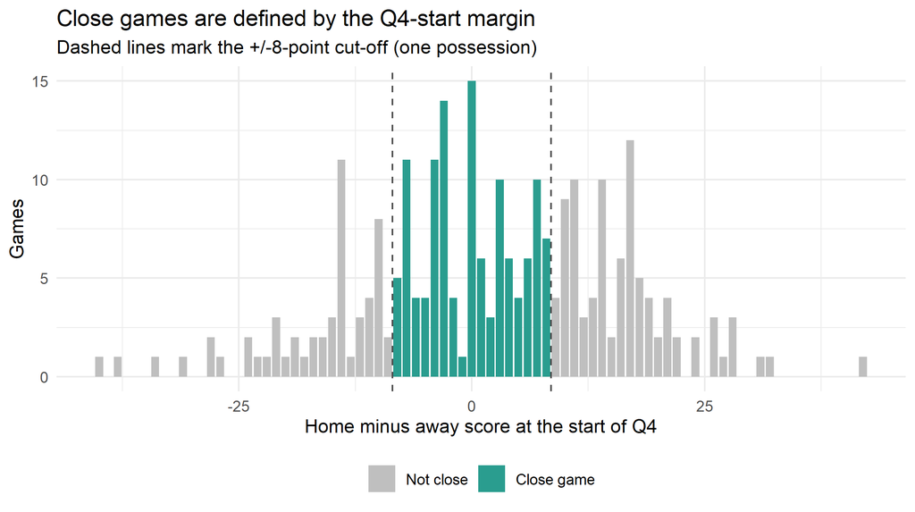

```r
side_colors <- c(Home = "#1f77b4", Away = "#d62728")
theme_set(theme_minimal(base_size = 11))

# 1. Distribution of the Q4-start margin and where the close-game cut-off falls
margin_counts <- nfc_north_games %>%
  count(q4_start_diff) %>%
  complete(q4_start_diff = seq(min(nfc_north_games$q4_start_diff),
                               max(nfc_north_games$q4_start_diff)),
           fill = list(n = 0)) %>%
  mutate(close_game = abs(q4_start_diff) <= close_threshold)

ggplot(margin_counts, aes(q4_start_diff, n, fill = close_game)) +
  geom_col(width = 0.85) +
  geom_vline(xintercept = c(-close_threshold - 0.5, close_threshold + 0.5),
             linetype = "dashed", color = "grey30") +
  scale_fill_manual(values = c(`TRUE` = "#2a9d8f", `FALSE` = "grey75"),
                    labels = c(`TRUE` = "Close game", `FALSE` = "Not close"),
                    name = NULL) +
  labs(x = "Home minus away score at the start of Q4",
       y = "Games",
       title = "Close games are defined by the Q4-start margin",
       subtitle = paste0("Dashed lines mark the +/-", close_threshold,
                         "-point cut-off (one possession)")) +
  theme(legend.position = "bottom")
```

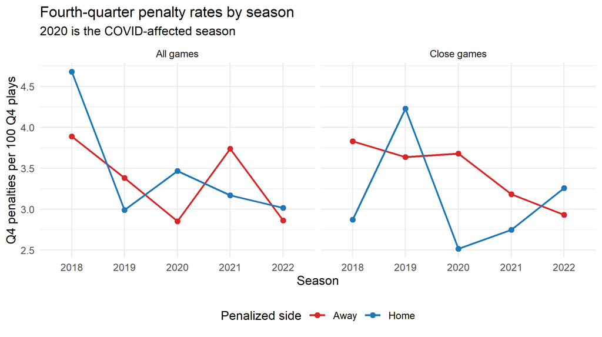

```r
# 2. Q4 penalty rate per 100 Q4 plays, by season and penalized side
rate_plot_data <- nfc_north_games %>%
  mutate(subset = if_else(is_close_game, "Close games", "All games")) %>%
  group_by(season, subset) %>%
  summarise(home = 100 * sum(q4_penalties_home) / sum(q4_plays),
            away = 100 * sum(q4_penalties_away) / sum(q4_plays),
            .groups = "drop") %>%
  pivot_longer(c(home, away), names_to = "side", values_to = "per_100_plays") %>%
  mutate(side = str_to_title(side))

ggplot(rate_plot_data, aes(factor(season), per_100_plays, color = side, group = side)) +
  geom_line(linewidth = 0.8) +
  geom_point(size = 2) +
  facet_wrap(~subset, nrow = 1) +
  scale_color_manual(values = side_colors, name = "Penalized side") +
  labs(x = "Season", y = "Q4 penalties per 100 Q4 plays",
       title = "Fourth-quarter penalty rates by season",
       subtitle = "2020 is the COVID-affected season") +
  theme(legend.position = "bottom")
```

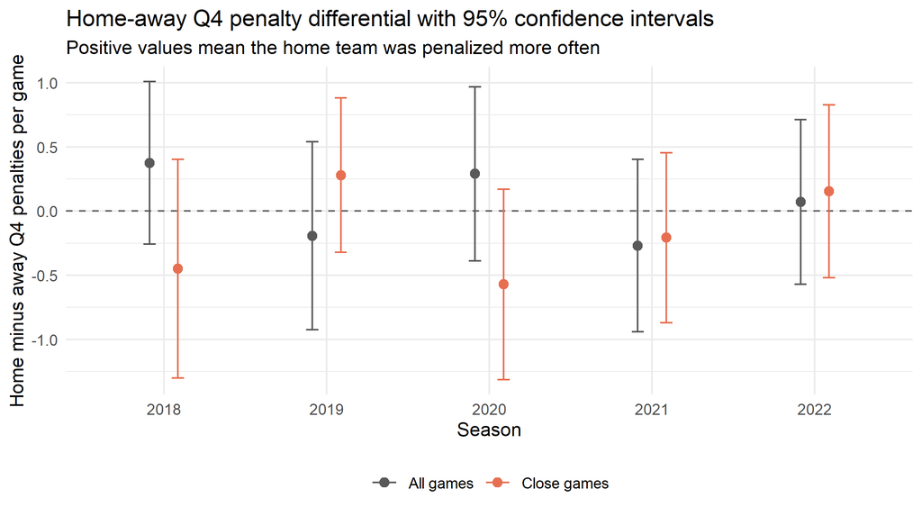

```r
# 3. Game-level home-minus-away differential with 95% confidence intervals
diff_plot_data <- nfc_north_games %>%
  mutate(subset = if_else(is_close_game, "Close games", "All games")) %>%
  group_by(season, subset) %>%
  summarise(n = n(),
            mean_diff = mean(q4_penalty_diff),
            se = sd(q4_penalty_diff) / sqrt(n()),
            .groups = "drop") %>%
  mutate(ci = qt(0.975, n - 1) * se)

ggplot(diff_plot_data, aes(factor(season), mean_diff, color = subset, group = subset)) +
  geom_hline(yintercept = 0, linetype = "dashed", color = "grey40") +
  geom_errorbar(aes(ymin = mean_diff - ci, ymax = mean_diff + ci),
                width = 0.15, position = position_dodge(width = 0.35)) +
  geom_point(size = 2.4, position = position_dodge(width = 0.35)) +
  scale_color_manual(values = c(`Close games` = "#e76f51", `All games` = "grey35"),
                     name = NULL) +
  labs(x = "Season",
       y = "Home minus away Q4 penalties per game",
       title = "Home-away Q4 penalty differential with 95% confidence intervals",
       subtitle = "Positive values mean the home team was penalized more often") +
  theme(legend.position = "bottom")
```

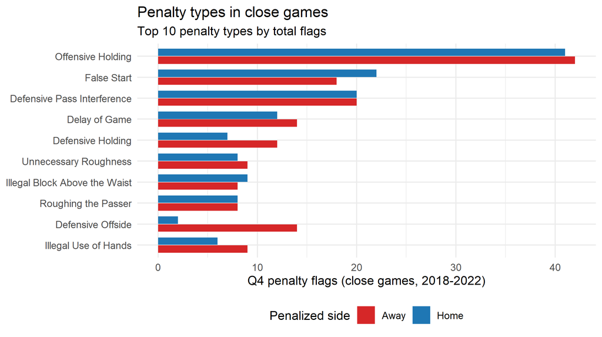

```r
# 4. Most common Q4 penalty types in close games, by penalized side
type_counts <- q4_penalty_plays %>%
  inner_join(select(nfc_north_games, game_id, is_close_game), by = "game_id") %>%
  filter(is_close_game) %>%
  count(penalty_type, penalized_side)

top_types <- type_counts %>%
  group_by(penalty_type) %>%
  summarise(total = sum(n), .groups = "drop") %>%
  slice_max(total, n = 10) %>%
  pull(penalty_type)

type_counts %>%
  filter(penalty_type %in% top_types) %>%
  mutate(penalty_type = fct_reorder(penalty_type, n, sum)) %>%
  ggplot(aes(n, penalty_type, fill = penalized_side)) +
  geom_col(position = position_dodge(width = 0.75), width = 0.7) +
  scale_fill_manual(values = side_colors, name = "Penalized side") +
  labs(x = "Q4 penalty flags (close games, 2018-2022)", y = NULL,
       title = "Penalty types in close games",
       subtitle = "Top 10 penalty types by total flags") +
  theme(legend.position = "bottom")
```

## 8. Statistical inference

The estimand is the change in the **home-minus-away Q4 penalty differential** in 2020 relative to the other four seasons, estimated at the game level. A positive coefficient means the home team was penalized relatively more in 2020.

```r
close_games <- nfc_north_games %>% filter(is_close_game)

models <- list(
  "All games, unadjusted" =
    lm(q4_penalty_diff ~ covid_2020, data = nfc_north_games),
  "All games, + close-game indicator + Q4 plays" =
    lm(q4_penalty_diff ~ covid_2020 + is_close_game + q4_plays, data = nfc_north_games),
  "Close games only, + Q4 plays (primary)" =
    lm(q4_penalty_diff ~ covid_2020 + q4_plays, data = close_games),
  "All games, 2020 x close-game interaction" =
    lm(q4_penalty_diff ~ covid_2020 * is_close_game + q4_plays, data = nfc_north_games),
  "Close games, + division-team fixed effects" =
    lm(q4_penalty_diff ~ covid_2020 + q4_plays + division_team, data = close_games)
)

model_table <- imap_dfr(models, function(model, label) {
  n_obs <- nobs(model)
  robust_tidy(model) %>%
    filter(term == "covid_2020") %>%
    transmute(model = label, n = n_obs, estimate, std.error,
              conf.low, conf.high, p.value)
})

model_table %>%
  mutate(model = fct_inorder(model)) %>%
  kable(digits = 3,
        col.names = c("Model", "N", "2020 estimate",
                      if (hc3_available) "Robust SE (HC3)" else "OLS SE",
                      "95% CI low", "95% CI high", "p-value"),
        caption = paste0("Estimated 2020 change in the home-minus-away Q4 penalty ",
                         "differential (penalties per game, home minus away)."))
```

Estimated 2020 change in the home-minus-away Q4 penalty differential (penalties per game, home minus away).

| Model | N | 2020 estimate | Robust SE (HC3) | 95% CI low | 95% CI high | p-value |
| --- | --- | --- | --- | --- | --- | --- |
| All games, unadjusted | 264 | -0.048 | 0.277 | -0.594 | 0.498 | 0.862 |
| All games, + close-game indicator + Q4 plays | 264 | -0.066 | 0.277 | -0.611 | 0.479 | 0.812 |
| Close games only, + Q4 plays (primary) | 121 | -0.483 | 0.400 | -1.276 | 0.309 | 0.229 |
| All games, 2020 x close-game interaction | 264 | 0.272 | 0.377 | -0.469 | 1.014 | 0.470 |
| Close games, + division-team fixed effects | 121 | -0.464 | 0.413 | -1.283 | 0.355 | 0.264 |

Standard errors are HC3 heteroskedasticity-robust when the `sandwich` package is installed; otherwise the same columns contain conventional OLS standard errors. The estimate and 95% interval are computed from that standard error.

```r
primary_model <- models[["Close games only, + Q4 plays (primary)"]]

robust_tidy(primary_model) %>%
  kable(digits = 3,
        col.names = c("Term", "Estimate",
                      if (hc3_available) "Robust SE (HC3)" else "OLS SE",
                      "t", "p-value", "95% CI low", "95% CI high"),
        caption = "Primary model: close games only, game-level Q4 penalty differential.")
```

Primary model: close games only, game-level Q4 penalty differential.

| Term | Estimate | Robust SE (HC3) | t | p-value | 95% CI low | 95% CI high |
| --- | --- | --- | --- | --- | --- | --- |
| (Intercept) | 1.178 | 1.229 | 0.958 | 0.340 | -1.256 | 3.613 |
| covid_2020 | -0.483 | 0.400 | -1.208 | 0.229 | -1.276 | 0.309 |
| q4_plays | -0.026 | 0.027 | -0.971 | 0.334 | -0.078 | 0.027 |

```r
primary_coef <- robust_tidy(primary_model) %>% filter(term == "covid_2020")
interaction_model <- models[["All games, 2020 x close-game interaction"]]
interaction_coef <- robust_tidy(interaction_model) %>%
  filter(term == "covid_2020:is_close_gameTRUE")

covid_close_est <- primary_coef$estimate
covid_close_lo <- primary_coef$conf.low
covid_close_hi <- primary_coef$conf.high
covid_close_p <- primary_coef$p.value
did_est <- interaction_coef$estimate
did_lo <- interaction_coef$conf.low
did_hi <- interaction_coef$conf.high
did_p <- interaction_coef$p.value
```

In close games, the 2020 change in the home-minus-away differential is -0.48 penalties per game (95% CI -1.28 to 0.31, p = 0.229). The adjusted difference-in-differences estimate from the interaction model is -0.81 (95% CI -1.91 to 0.28, p = 0.144). Both intervals include zero. At the 95% level, shifts larger than about 1.91 penalties per game toward the away team being penalized relatively more, or larger than about 0.28 penalties per game toward the home team being penalized relatively more, are ruled out - but within that range the estimate is too imprecise to distinguish a real change from noise.

### Hypothesis tests and interval estimates

```r
diff_2020 <- close_games$q4_penalty_diff[close_games$covid_2020 == 1]
diff_other <- close_games$q4_penalty_diff[close_games$covid_2020 == 0]

welch_close <- t.test(diff_2020, diff_other)
wilcox_close <- wilcox.test(diff_2020, diff_other, exact = FALSE, conf.int = TRUE)

perm_test_diff <- function(data, B = 10000) {
  observed <- mean(data$q4_penalty_diff[data$covid_2020 == 1]) -
    mean(data$q4_penalty_diff[data$covid_2020 == 0])
  n_2020 <- sum(data$covid_2020 == 1)
  perm_stats <- replicate(B, {
    idx <- sample(nrow(data), n_2020)
    mean(data$q4_penalty_diff[idx]) - mean(data$q4_penalty_diff[-idx])
  })
  tibble(observed = observed,
         p_value = (sum(abs(perm_stats) >= abs(observed)) + 1) / (B + 1))
}

set.seed(2026)
perm_close <- perm_test_diff(close_games)

bootstrap_diff_ci <- function(data, B = 5000) {
  a <- data$q4_penalty_diff[data$covid_2020 == 1]
  b <- data$q4_penalty_diff[data$covid_2020 == 0]
  reps <- replicate(B, mean(sample(a, length(a), replace = TRUE)) -
                      mean(sample(b, length(b), replace = TRUE)))
  quantile(reps, c(0.025, 0.975))
}

set.seed(2026)
boot_close <- bootstrap_diff_ci(close_games)

tibble(
  method = c("Welch t-test (game level)", "Wilcoxon rank-sum (location shift)",
             "Permutation test (10,000 draws)", "Bootstrap percentile CI (5,000 draws)"),
  estimate = c(unname(welch_close$estimate[1] - welch_close$estimate[2]),
               unname(wilcox_close$estimate),
               perm_close$observed,
               perm_close$observed),
  conf.low = c(welch_close$conf.int[1], wilcox_close$conf.int[1], boot_close[1], boot_close[1]),
  conf.high = c(welch_close$conf.int[2], wilcox_close$conf.int[2], boot_close[2], boot_close[2]),
  p.value = c(welch_close$p.value, wilcox_close$p.value, perm_close$p_value, NA)
) %>%
  kable(digits = 3,
        caption = paste0("Close games: 2020 minus other seasons in the game-level ",
                         "home-minus-away Q4 penalty differential."))
```

Close games: 2020 minus other seasons in the game-level home-minus-away Q4 penalty differential.

| method | estimate | conf.low | conf.high | p.value |
| --- | --- | --- | --- | --- |
| Welch t-test (game level) | -0.531 | -1.334 | 0.272 | 0.187 |
| Wilcoxon rank-sum (location shift) | 0.000 | -1.000 | 0.000 | 0.224 |
| Permutation test (10,000 draws) | -0.531 | -1.316 | 0.217 | 0.196 |
| Bootstrap percentile CI (5,000 draws) | -0.531 | -1.316 | 0.217 | NA |

The permutation test uses 10,000 random reassignments of the 2020 label across games; the bootstrap resamples games within each period. Both respect the game-level unit and make no normal-theory assumption. The Wilcoxon row reports a shift in location (a robust analogue of the 2020-versus-other difference), not a difference in means, so its estimate is not directly comparable to the Welch estimate.

```r
paired_period_table <- close_games %>%
  group_by(period = if_else(covid_2020 == 1, "2020 (COVID-19)", "2018-19, 2021-22")) %>%
  group_modify(~ {
    tt <- t.test(.x$q4_penalties_home, .x$q4_penalties_away, paired = TRUE)
    tibble(
      games = nrow(.x),
      home_per_game = mean(.x$q4_penalties_home),
      away_per_game = mean(.x$q4_penalties_away),
      mean_diff = mean(.x$q4_penalties_home - .x$q4_penalties_away),
      conf.low = tt$conf.int[1],
      conf.high = tt$conf.int[2],
      p.value = tt$p.value
    )
  }) %>%
  ungroup()

paired_period_table %>%
  kable(digits = 3,
        caption = "Paired within-game comparison of home vs. away Q4 penalties, close games.")
```

Paired within-game comparison of home vs. away Q4 penalties, close games.

| period | games | home_per_game | away_per_game | mean_diff | conf.low | conf.high | p.value |
| --- | --- | --- | --- | --- | --- | --- | --- |
| 2018-19, 2021-22 | 100 | 1.550 | 1.59 | -0.040 | -0.371 | 0.291 | 0.811 |
| 2020 (COVID-19) | 21 | 1.238 | 1.81 | -0.571 | -1.313 | 0.171 | 0.124 |

Within close games, the home-away gap is -0.57 penalties per game in 2020 (95% CI -1.31 to 0.17, p = 0.124) versus -0.04 in the other seasons (95% CI -0.37 to 0.29, p = 0.811).

```r
share_models <- list(
  "All games" = glm(cbind(q4_penalties_home, q4_penalties_away) ~ covid_2020,
                    data = nfc_north_games, family = quasibinomial),
  "Close games" = glm(cbind(q4_penalties_home, q4_penalties_away) ~ covid_2020,
                      data = close_games, family = quasibinomial)
)

share_model_table <- imap_dfr(share_models, function(model, label) {
  tidy(model, conf.int = TRUE, exponentiate = TRUE) %>%
    filter(term == "covid_2020") %>%
    transmute(model = label, odds_ratio = estimate, conf.low, conf.high, p.value)
})

share_model_table %>%
  kable(digits = 3,
        caption = paste0("Quasi-binomial model for the home share of Q4 penalties: ",
                         "odds ratio for 2020 vs. other seasons (home = penalized side)."))
```

Quasi-binomial model for the home share of Q4 penalties: odds ratio for 2020 vs. other seasons (home = penalized side).

| model | odds_ratio | conf.low | conf.high | p.value |
| --- | --- | --- | --- | --- |
| All games | 0.968 | 0.689 | 1.359 | 0.852 |
| Close games | 0.702 | 0.414 | 1.176 | 0.185 |

This model treats each game as one binomial observation (home vs. away penalties) and uses quasi-binomial variance to allow for overdispersion, so it weights games with more penalty calls more heavily without treating plays as independent. An odds ratio below 1 means home teams were relatively less likely to be the penalized side in 2020.

### Secondary: pre-snap vs. judgment penalties

```r
category_models <- list(
  "Procedural, close games" = lm(q4_procedural_diff ~ covid_2020 + q4_plays, data = close_games),
  "Judgment, close games" = lm(q4_discretionary_diff ~ covid_2020 + q4_plays, data = close_games),
  "Procedural, all games" = lm(q4_procedural_diff ~ covid_2020 + q4_plays, data = nfc_north_games),
  "Judgment, all games" = lm(q4_discretionary_diff ~ covid_2020 + q4_plays, data = nfc_north_games)
)

imap_dfr(category_models, function(model, label) {
  n_obs <- nobs(model)
  robust_tidy(model) %>%
    filter(term == "covid_2020") %>%
    transmute(model = label, n = n_obs, estimate, conf.low, conf.high, p.value)
}) %>%
  kable(digits = 3,
        caption = paste0("Exploratory: 2020 change in home-minus-away penalty ",
                         "differential by penalty category (game level)."))
```

Exploratory: 2020 change in home-minus-away penalty differential by penalty category (game level).

| model | n | estimate | conf.low | conf.high | p.value |
| --- | --- | --- | --- | --- | --- |
| Procedural, close games | 121 | -0.049 | -0.430 | 0.331 | 0.797 |
| Judgment, close games | 121 | -0.240 | -0.885 | 0.405 | 0.463 |
| Procedural, all games | 264 | 0.011 | -0.262 | 0.285 | 0.936 |
| Judgment, all games | 264 | -0.010 | -0.430 | 0.410 | 0.962 |

These category models are secondary and exploratory. The pre-snap group (false start, delay of game, illegal formation/shift, neutral zone infraction) is the closest available proxy for crowd-noise-sensitive calls; the judgment group (holding, pass interference, roughing, unnecessary roughness, etc.) is the closest proxy for discretionary officiating. Neither shows a statistically distinguishable 2020 shift, and neither can separate officiating behavior from changes in how teams played.

## 9. Optional check: fourth-quarter offensive EPA

If home-field advantage (crowd effects on players, travel, or officiating) changed in 2020, Q4 efficiency differences between home and away offenses are another place to look. EPA is available for every pass and run play, so the game-level paired difference is well defined.

```r
epa_games <- nfc_north_games %>%
  filter(!is.na(q4_epa_per_play_home), !is.na(q4_epa_per_play_away))

epa_season_table <- epa_games %>%
  group_by(season) %>%
  summarise(
    games = n(),
    home_epa_per_play = mean(q4_epa_per_play_home),
    away_epa_per_play = mean(q4_epa_per_play_away),
    mean_diff = mean(q4_epa_diff),
    sd_diff = sd(q4_epa_diff),
    se_diff = sd(q4_epa_diff) / sqrt(n()),
    .groups = "drop"
  ) %>%
  mutate(ci = qt(0.975, games - 1) * se_diff)

epa_season_table %>%
  select(-se_diff) %>%
  kable(digits = 4,
        caption = "Q4 offensive EPA per play, all games with usable EPA.")
```

Q4 offensive EPA per play, all games with usable EPA.

| season | games | home_epa_per_play | away_epa_per_play | mean_diff | sd_diff | ci |
| --- | --- | --- | --- | --- | --- | --- |
| 2018 | 52 | -0.0667 | -0.0487 | -0.0180 | 0.5708 | 0.1589 |
| 2019 | 51 | -0.1043 | 0.0218 | -0.1262 | 0.5941 | 0.1671 |
| 2020 | 52 | -0.0178 | 0.0628 | -0.0806 | 0.4892 | 0.1362 |
| 2021 | 55 | 0.0041 | -0.0392 | 0.0433 | 0.4668 | 0.1262 |
| 2022 | 54 | -0.0687 | -0.0672 | -0.0015 | 0.5617 | 0.1533 |

```r
epa_close <- epa_games %>% filter(is_close_game)
epa_test <- t.test(epa_close$q4_epa_diff[epa_close$covid_2020 == 1],
                   epa_close$q4_epa_diff[epa_close$covid_2020 == 0])

tibble(
  comparison = c("Close games: 2020 vs. other seasons",
                 "Close games: 2020 home-away difference vs. 0",
                 "Close games: other seasons home-away difference vs. 0"),
  estimate = c(unname(epa_test$estimate[1] - epa_test$estimate[2]),
               mean(epa_close$q4_epa_diff[epa_close$covid_2020 == 1]),
               mean(epa_close$q4_epa_diff[epa_close$covid_2020 == 0])),
  conf.low = c(epa_test$conf.int[1], NA, NA),
  conf.high = c(epa_test$conf.int[2], NA, NA),
  p.value = c(epa_test$p.value,
              t.test(epa_close$q4_epa_diff[epa_close$covid_2020 == 1])$p.value,
              t.test(epa_close$q4_epa_diff[epa_close$covid_2020 == 0])$p.value)
) %>%
  kable(digits = 4,
        caption = "Home-minus-away Q4 offensive EPA per play in close games.")
```

Home-minus-away Q4 offensive EPA per play in close games.

| comparison | estimate | conf.low | conf.high | p.value |
| --- | --- | --- | --- | --- |
| Close games: 2020 vs. other seasons | -0.1795 | -0.4266 | 0.0677 | 0.1485 |
| Close games: 2020 home-away difference vs. 0 | -0.1719 | NA | NA | 0.1303 |
| Close games: other seasons home-away difference vs. 0 | 0.0076 | NA | NA | 0.8861 |

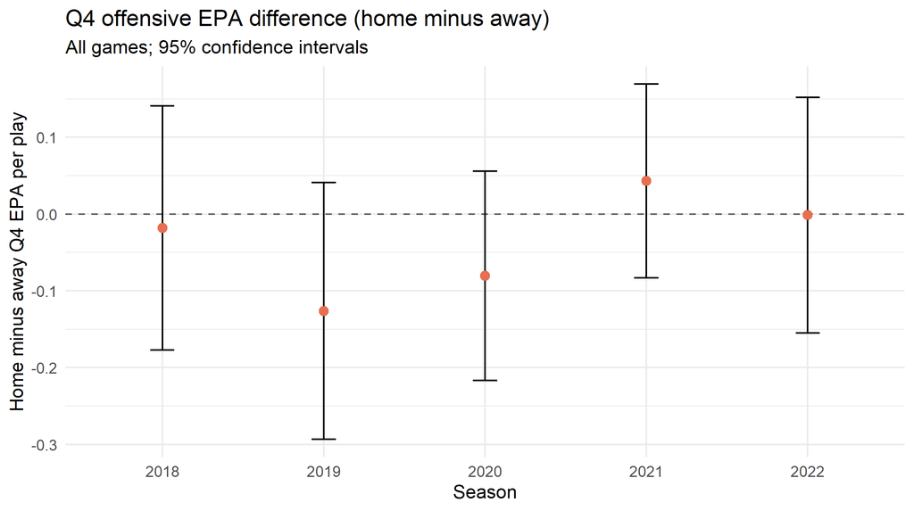

```r
ggplot(epa_season_table, aes(factor(season), mean_diff)) +
  geom_hline(yintercept = 0, linetype = "dashed", color = "grey40") +
  geom_errorbar(aes(ymin = mean_diff - ci, ymax = mean_diff + ci), width = 0.15) +
  geom_point(size = 2.4, color = "#e76f51") +
  labs(x = "Season", y = "Home minus away Q4 EPA per play",
       title = "Q4 offensive EPA difference (home minus away)",
       subtitle = "All games; 95% confidence intervals") +
  theme_minimal(base_size = 11)
```

EPA differences are small and imprecise, and they mix changes in team quality, game script, and officiating. They are reported as a descriptive complement, not as evidence for or against a crowd effect.

## 10. Summary of results

- The NFC North sample contains 264 regular-season games, 121 of them close at the start of Q4 and 21 of those close games in 2020.
- The game-level home-minus-away Q4 penalty differential is close to zero in most seasons. Its 2020 value is slightly negative (home teams were penalized slightly less often than away teams), but the confidence interval includes zero in every model, and the adjusted difference-in-differences estimate is also compatible with no change.
- The home share of Q4 penalties in close games was lower in 2020, but the quasi-binomial odds ratio is not statistically distinguishable from 1.
- Neither the pre-snap (crowd-noise proxy) nor the judgment penalty category shows a clear 2020 shift; the same is true for individual penalty types descriptively.
- Q4 offensive EPA differences are small and imprecise.

Taken together, this NFC North analysis finds **no statistically detectable change** in fourth-quarter home-away penalty patterns during 2020, in close games or overall. That is a statement about the precision of this sample, not proof that crowds do not matter, and the design cannot separate crowd absence from the other ways the 2020 season differed.

## 11. Limitations and assumptions

- **Observational, not causal.** 2020 differed from other seasons in many ways beyond crowds: scheduling, no preseason, opt-outs, roster and rule changes, travel, and reduced attendance that varied by team and state. The `covid_2020` coefficient is a descriptive season contrast, not an estimate of a crowd effect, and these results cannot establish referee bias in either direction.
- **Sample size and precision.** The NFC North sample has 264 games, 121 of them close, and only 21 close games in 2020. Confidence intervals are therefore wide; a null result means “no detectable change with this sample”, not “no change”.
- **Home is the designated home team, not measured attendance.** The data contain no attendance variable. Some 2020 games had limited spectators, so the contrast is “2020 season” versus “other seasons”, not “empty stadium” versus “full stadium”.
- **Penalty records have limits.** A flagged play records one penalized team and one penalty type; offsetting or multiple fouls on a play, and some declined penalties, may be represented incompletely. Penalty yards are kept as a secondary measure but the analysis focuses on counts.
- **Q4-start scores are derived, not supplied.** The primary derivation uses the pre-play score of the first Q4 play with known possession. It was validated against end-of-Q3 cumulative scores for all games (0 mismatches), and no Q4-start score exceeds a team’s final score.
- **Play-filtering.** Plays without a `play_type` (timeouts, quarter-end markers) are dropped following the repository convention; none of the dropped plays is a penalty flag, which was verified above. Q4 “plays” therefore counts offensive, special-teams, and no-play penalty rows, which is why penalty rates are reported per 100 Q4 plays rather than per offensive snap.
- **Model choice.** OLS on game-level differentials is used because each game is one independent observation and the coefficient is directly interpretable as penalties per game. The quasi-binomial model is a robustness check for the home share of penalties. Several secondary tests are reported without multiplicity adjustment and should be read as exploratory.
- **EPA** is per-play and opponent-adjusted but not garbage-time filtered; the EPA comparison is descriptive and mixes team quality with game situation.
- **Overtime is outside the Q4 analysis.** Q4 penalty counts and Q4 EPA stop at the end of regulation; overtime plays are not included, so games that went to overtime contribute only their fourth-quarter plays.

## 12. Merge preparation for the four-division dataset

### Output files

```r
dir.create("data", showWarnings = FALSE)

write_csv(nfc_north_games, "data/gerry_nfc_north_game_level.csv")
write_csv(q4_penalty_plays, "data/gerry_nfc_north_q4_penalties.csv")

tibble(
  file = c("data/gerry_nfc_north_game_level.csv",
           "data/gerry_nfc_north_q4_penalties.csv"),
  rows = c(nrow(nfc_north_games), nrow(q4_penalty_plays)),
  columns = c(ncol(nfc_north_games), ncol(q4_penalty_plays)),
  grain = c("one row per game", "one row per Q4 penalty flag")
) %>%
  kable(caption = "Files written for the later divisional merge.")
```

Files written for the later divisional merge.

| file | rows | columns | grain |
| --- | --- | --- | --- |
| data/gerry_nfc_north_game_level.csv | 264 | 38 | one row per game |
| data/gerry_nfc_north_q4_penalties.csv | 843 | 16 | one row per Q4 penalty flag |

CSV files store no types, so the round trip below re-reads the game-level file with an explicit column specification and verifies that the documented key types survive:

```r
roundtrip <- read_csv(
  "data/gerry_nfc_north_game_level.csv",
  show_col_types = FALSE,
  col_types = cols(
    .default = col_guess(),
    season = col_integer(),
    week = col_integer(),
    q4_plays = col_integer(),
    q4_penalties_home = col_integer(),
    q4_penalties_away = col_integer(),
    q4_penalty_diff = col_integer(),
    is_close_game = col_logical()
  )
)

stopifnot(
  identical(names(roundtrip), names(nfc_north_games)),
  nrow(roundtrip) == nrow(nfc_north_games),
  !anyDuplicated(roundtrip$game_id),
  is.character(roundtrip$game_id),
  is.integer(roundtrip$season),
  is.integer(roundtrip$week),
  is.logical(roundtrip$is_close_game),
  is.integer(roundtrip$q4_penalties_home),
  is.integer(roundtrip$q4_penalties_away),
  is.integer(roundtrip$q4_penalty_diff)
)

tibble(
  column = c("game_id", "season", "is_close_game", "q4_penalties_home"),
  class_after_read = map_chr(roundtrip[c("game_id", "season", "is_close_game",
                                         "q4_penalties_home")], ~ class(.x)[1])
) %>%
  kable(caption = "Type check after the CSV round trip (game-level file).")
```

Type check after the CSV round trip (game-level file).

| column | class_after_read |
| --- | --- |
| game_id | character |
| season | integer |
| is_close_game | logical |
| q4_penalties_home | integer |

### Shared schema (required for the combined dataset)

These fields must exist, with the same names and types, in every member’s game-level file. `division` is the member’s division label; `division_team` is member-specific and is not carried into the combined file. CSV files do not store types, so the combine helper below re-applies the documented types after reading.

```r
schema_required <- tribble(
  ~field, ~type, ~description,
  "game_id", "character", "nflverse game identifier; unique key for the merge",
  "season", "integer", "2018-2022 season",
  "week", "integer", "Regular-season week",
  "division", "character", "Member division label, e.g. 'NFC North'",
  "home_team", "character", "Home team abbreviation",
  "away_team", "character", "Away team abbreviation",
  "home_score", "integer", "Final home score (schedule)",
  "away_score", "integer", "Final away score (schedule)",
  "final_diff", "integer", "home_score - away_score",
  "q4_start_home_score", "integer", "Home score at the start of Q4 (pre-play derivation)",
  "q4_start_away_score", "integer", "Away score at the start of Q4 (pre-play derivation)",
  "q4_start_diff", "integer", "q4_start_home_score - q4_start_away_score",
  "is_close_game", "logical", "abs(q4_start_diff) <= 8",
  "q4_plays", "integer", "Q4 plays with a non-missing play_type",
  "q4_penalties_home", "integer", "Q4 penalty flags against the home team",
  "q4_penalties_away", "integer", "Q4 penalty flags against the away team",
  "q4_penalty_diff", "integer", "q4_penalties_home - q4_penalties_away",
  "covid_2020", "integer", "1 for the 2020 season, 0 otherwise"
)

extra_fields <- setdiff(names(nfc_north_games), schema_required$field)

bind_rows(
  schema_required %>% mutate(present_in_this_file = field %in% names(nfc_north_games)),
  tibble(
    field = extra_fields,
    type = map_chr(nfc_north_games[extra_fields], ~ class(.x)[1]),
    description = "Additional derived field (optional in the combined file)",
    present_in_this_file = TRUE
  )
) %>%
  kable(caption = "Game-level schema and field inventory for the divisional merge.")
```

Game-level schema and field inventory for the divisional merge.

| field | type | description | present_in_this_file |
| --- | --- | --- | --- |
| game_id | character | nflverse game identifier; unique key for the merge | TRUE |
| season | integer | 2018-2022 season | TRUE |
| week | integer | Regular-season week | TRUE |
| division | character | Member division label, e.g. ‘NFC North’ | TRUE |
| home_team | character | Home team abbreviation | TRUE |
| away_team | character | Away team abbreviation | TRUE |
| home_score | integer | Final home score (schedule) | TRUE |
| away_score | integer | Final away score (schedule) | TRUE |
| final_diff | integer | home_score - away_score | TRUE |
| q4_start_home_score | integer | Home score at the start of Q4 (pre-play derivation) | TRUE |
| q4_start_away_score | integer | Away score at the start of Q4 (pre-play derivation) | TRUE |
| q4_start_diff | integer | q4_start_home_score - q4_start_away_score | TRUE |
| is_close_game | logical | abs(q4_start_diff) <= 8 | TRUE |
| q4_plays | integer | Q4 plays with a non-missing play_type | TRUE |
| q4_penalties_home | integer | Q4 penalty flags against the home team | TRUE |
| q4_penalties_away | integer | Q4 penalty flags against the away team | TRUE |
| q4_penalty_diff | integer | q4_penalties_home - q4_penalties_away | TRUE |
| covid_2020 | integer | 1 for the 2020 season, 0 otherwise | TRUE |
| division_team | character | Additional derived field (optional in the combined file) | TRUE |
| is_division_matchup | logical | Additional derived field (optional in the combined file) | TRUE |
| overtime | integer | Additional derived field (optional in the combined file) | TRUE |
| roof | character | Additional derived field (optional in the combined file) | TRUE |
| surface | character | Additional derived field (optional in the combined file) | TRUE |
| q4_penalty_rate_home | numeric | Additional derived field (optional in the combined file) | TRUE |
| q4_penalty_rate_away | numeric | Additional derived field (optional in the combined file) | TRUE |
| q4_penalty_yards_home | numeric | Additional derived field (optional in the combined file) | TRUE |
| q4_penalty_yards_away | numeric | Additional derived field (optional in the combined file) | TRUE |
| q4_pen_procedural_home | integer | Additional derived field (optional in the combined file) | TRUE |
| q4_pen_procedural_away | integer | Additional derived field (optional in the combined file) | TRUE |
| q4_procedural_diff | integer | Additional derived field (optional in the combined file) | TRUE |
| q4_pen_discretionary_home | integer | Additional derived field (optional in the combined file) | TRUE |
| q4_pen_discretionary_away | integer | Additional derived field (optional in the combined file) | TRUE |
| q4_discretionary_diff | integer | Additional derived field (optional in the combined file) | TRUE |
| q4_epa_per_play_home | numeric | Additional derived field (optional in the combined file) | TRUE |
| q4_epa_per_play_away | numeric | Additional derived field (optional in the combined file) | TRUE |
| q4_epa_diff | numeric | Additional derived field (optional in the combined file) | TRUE |
| q4_off_plays_home | integer | Additional derived field (optional in the combined file) | TRUE |
| q4_off_plays_away | integer | Additional derived field (optional in the combined file) | TRUE |

```r
stopifnot(
  is.character(nfc_north_games$game_id),
  !anyNA(nfc_north_games$game_id),
  !anyDuplicated(nfc_north_games$game_id),
  is.integer(nfc_north_games$season),
  is.integer(nfc_north_games$week),
  is.character(nfc_north_games$division),
  is.character(nfc_north_games$home_team),
  is.character(nfc_north_games$away_team),
  is.integer(nfc_north_games$home_score),
  is.integer(nfc_north_games$away_score),
  is.integer(nfc_north_games$final_diff),
  is.integer(nfc_north_games$q4_start_home_score),
  is.integer(nfc_north_games$q4_start_away_score),
  is.integer(nfc_north_games$q4_start_diff),
  is.logical(nfc_north_games$is_close_game),
  is.integer(nfc_north_games$q4_plays),
  is.integer(nfc_north_games$q4_penalties_home),
  is.integer(nfc_north_games$q4_penalties_away),
  is.integer(nfc_north_games$q4_penalty_diff),
  is.integer(nfc_north_games$covid_2020)
)
```

### Deduplicating overlapping interdivision games

Filtering on “at least one team from my division” means a game between two members’ divisions (for example GB vs. BAL, or CHI vs. CLE) appears in both members’ files. Games inside one division (for example CHI vs. GB) appear only in that division’s file. The planned combination rule is therefore:

1. Stack the four members’ game-level files (`bind_rows`).
2. **Verify** that every shared game-level field is identical across duplicate `game_id`s. Scores, Q4-start scores, close-game flags, and penalty counts are properties of the game, so any disagreement indicates a coding bug to fix, not something to overwrite silently.
3. Keep **one row per `game_id`**, and record which divisions contributed the game in `division` (`"AFC North; NFC North"`) plus `n_divisions`.
4. Drop the member-specific `division_team` field; team identity remains available through `home_team`/`away_team`, and team-to-division maps can be joined if needed.
5. Assert that no game is counted twice and that the combined row count equals the number of distinct `game_id`s.

```r
combine_division_files <- function(paths) {
  shared_fields <- c(
    "game_id", "season", "week", "home_team", "away_team",
    "home_score", "away_score", "final_diff",
    "q4_start_home_score", "q4_start_away_score", "q4_start_diff",
    "is_close_game", "q4_plays",
    "q4_penalties_home", "q4_penalties_away", "q4_penalty_diff", "covid_2020"
  )

  raw <- purrr::map_dfr(paths, readr::read_csv, show_col_types = FALSE) %>%
    # CSV round trips guess whole numbers as doubles; enforce the documented types
    mutate(
      season = as.integer(season),
      week = as.integer(week),
      home_score = as.integer(home_score),
      away_score = as.integer(away_score),
      final_diff = as.integer(final_diff),
      q4_start_home_score = as.integer(q4_start_home_score),
      q4_start_away_score = as.integer(q4_start_away_score),
      q4_start_diff = as.integer(q4_start_diff),
      is_close_game = as.logical(is_close_game),
      q4_plays = as.integer(q4_plays),
      q4_penalties_home = as.integer(q4_penalties_home),
      q4_penalties_away = as.integer(q4_penalties_away),
      q4_penalty_diff = as.integer(q4_penalty_diff),
      covid_2020 = as.integer(covid_2020)
    )

  # Fail loudly if duplicate games disagree on any game-level field
  conflicts <- raw %>%
    group_by(game_id) %>%
    summarise(across(all_of(setdiff(shared_fields, "game_id")), n_distinct),
              .groups = "drop") %>%
    filter(if_any(-game_id, ~ .x > 1))
  stopifnot(nrow(conflicts) == 0)

  raw %>%
    group_by(game_id) %>%
    summarise(
      n_divisions = n_distinct(division),
      across(all_of(setdiff(shared_fields, "game_id")), first),
      division = paste(sort(unique(division)), collapse = "; "),
      .groups = "drop"
    )
}

# Placeholder file names: replace with the other members' actual output files.
combined <- combine_division_files(c(
  "data/gerry_nfc_north_game_level.csv",
  "data/reuel_afc_north_game_level.csv",
  "data/member3_division_game_level.csv",
  "data/member4_division_game_level.csv"
))

stopifnot(!anyDuplicated(combined$game_id))
```

The penalty-level file is similarly stackable: `game_id` plus `play_id` identifies a penalty flag, and duplicates arise only for interdivision games. Its dedupe key should be `c("game_id", "play_id")`, with the same verification step before removing duplicates. As with the game-level file, re-apply `as.integer()` to `season`, `week`, and `play_id` after reading the CSVs so that types match across members.